# People Based ML - Targeting A Housing Subsidy

Shengqian Wang

Nov.05,2023

# Introduction

This analysis tries to address the deficiency for Emil City’s home repair tax credit program managed by the Housing and Community Development (HCD). The HCD’s analysis aims to change this status quo that the participation rate is low and utilize historical campaign data to develop a predictive model. The model aims to identify those more likely to respond to the program, thereby refining and focusing outreach efforts.

```r
options(scipen=10000000)

library(tidyverse)
library(kableExtra)
library(caret)
library(knitr)
library(pscl)
library(plotROC)
library(pROC)
library(lubridate)
```

```r
palette5 <- c("#981FAC","#CB0F8B","#FF006A","#FE4C35","#FE9900")
palette4 <- c("#981FAC","#FF006A","#FE4C35","#FE9900")
palette2 <- c("#981FAC","#FF006A")
housingSubsidy <- read.csv("https://raw.githubusercontent.com/urbanSpatial/Public-Policy-Analytics-Landing/master/DATA/Chapter6/housingSubsidy.csv")
```

## Data Exploration

Creating plots to explore how different numerical variables relate to homeowners’ participation in the program.

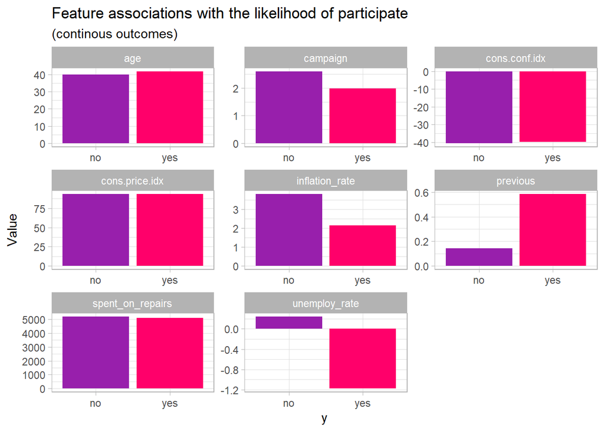

```r
housingSubsidy %>%
  dplyr::select(previous, unemploy_rate, cons.price.idx,
                cons.conf.idx, inflation_rate, campaign,
                age, spent_on_repairs, y) %>%
  gather(Variable, value, -y) %>%
  ggplot(aes(y, value, fill = y)) +
  geom_bar(position = "dodge", stat = "summary", fun = "mean") +
  facet_wrap(~Variable, scales = "free") +
  scale_fill_manual(values = palette2) +
   theme_light()+
  labs(x = "y", y = "Value",
    title = "Feature associations with the likelihood of participate",
    subtitle = "(continous outcomes)") +
  theme(legend.position = "none")
```

Plotting the curves for a better understanding of the distribution of different factors

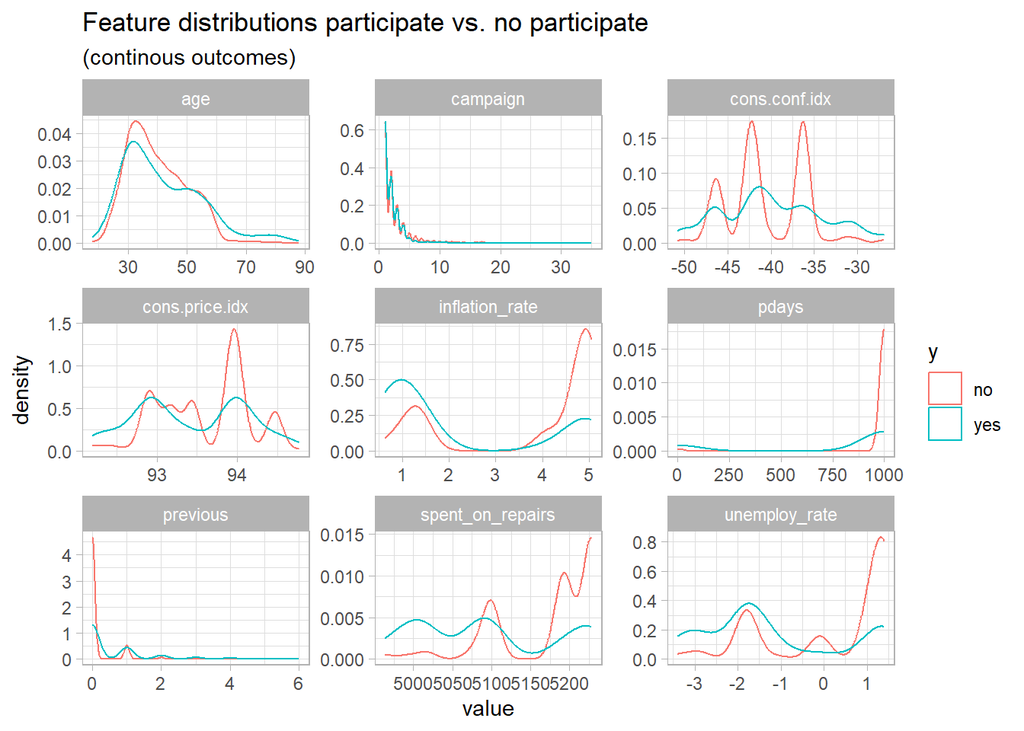

```r
housingSubsidy %>%
    dplyr::select(previous, unemploy_rate, cons.price.idx,
                cons.conf.idx, inflation_rate, campaign,
                age, spent_on_repairs, pdays,y) %>%
                gather(Variable, value, -y) %>%
    ggplot() +
    geom_density(aes(value, color=y), fill = "transparent") +
    facet_wrap(~Variable, scales = "free") +
    theme_light()+
    scale_fill_manual(values = palette2) +
    labs(title = "Feature distributions participate vs. no participate",
         subtitle = "(continous outcomes)")
```

Creating plots to explore how different categorical variables relate to homeowners’ participation in the program.

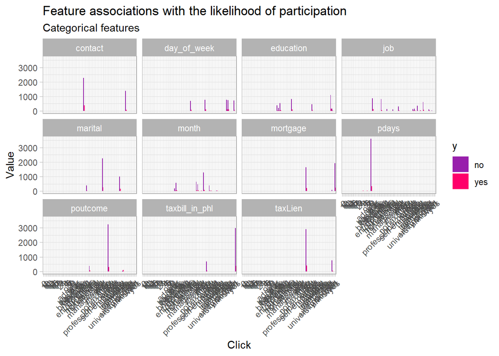

```r
housingSubsidy %>%
    dplyr::select(y,taxLien,taxbill_in_phl,poutcome,mortgage ,month ,marital ,job,pdays,education,day_of_week,contact) %>%
    gather(Variable, value, -y) %>%
    count(Variable, value, y) %>%
      ggplot(., aes(value, n, fill = y)) +
        geom_bar(position = "dodge", stat="identity") +
        facet_wrap(~Variable,ncol = 4, scales="fixed") +
        scale_fill_manual(values = palette2) +
        labs(x="Click", y="Value",
             title = "Feature associations with the likelihood of participation",
             subtitle = "Categorical features") +
         theme_light()+
        theme(axis.text.x = element_text(angle = 45, hjust = 1))
```

## Create A Logistic Regression Model

Then we remove outliers and splits the dataset to 65%-35% for model training and testing

```r
housingSubsidy <- subset(housingSubsidy,X != 3515) #remove the only yes for taxLien and edu
housingSubsidy <- subset(housingSubsidy,X != 3927)
set.seed(538)
trainIndex <- createDataPartition(housingSubsidy$y, p = .65,
                                  list = FALSE,
                                  times = 1)
housingSubsidyTrain <- housingSubsidy[ trainIndex,]
housingSubsidyTest  <- housingSubsidy[-trainIndex,]
```

We run our model with the dependent variable `y_numeric` and we use most of our variables in the regression. (See `dplyr::select`).

```r
housingSubsidyModel <- glm(y_numeric ~ .,
                  data=housingSubsidyTrain %>%
                  dplyr::select( -X,-y,-day_of_week,-pdays,-previous,-inflation_rate),
                  family="binomial" (link="logit"))

summary(housingSubsidyModel)
```

```
##
## Call:
## glm(formula = y_numeric ~ ., family = binomial(link = "logit"),
##     data = housingSubsidyTrain %>% dplyr::select(-X, -y, -day_of_week,
##         -pdays, -previous, -inflation_rate))
##
## Deviance Residuals:
##     Min       1Q   Median       3Q      Max
## -2.0980  -0.3917  -0.3145  -0.2380   2.8577
##
## Coefficients:
##                                  Estimate   Std. Error z value      Pr(>|z|)
## (Intercept)                  -262.1512045  106.5180791  -2.461      0.013851
## age                             0.0129540    0.0085897   1.508      0.131532
## jobblue-collar                 -0.0558052    0.2832636  -0.197      0.843821
## jobentrepreneur                 0.1293298    0.4496978   0.288      0.773659
## jobhousemaid                   -0.0505603    0.4910414  -0.103      0.917990
## jobmanagement                  -0.2094190    0.2979428  -0.703      0.482128
## jobretired                     -0.6810688    0.4225770  -1.612      0.107026
## jobself-employed               -1.0896084    0.5256931  -2.073      0.038199
## jobservices                     0.0807120    0.3086764   0.261      0.793724
## jobstudent                     -0.1501453    0.4550612  -0.330      0.741441
## jobtechnician                   0.0007766    0.2437275   0.003      0.997458
## jobunemployed                   0.2828983    0.4411193   0.641      0.521315
## jobunknown                     -1.0818949    0.9040391  -1.197      0.231410
## maritalmarried                  0.4026780    0.2672426   1.507      0.131865
## maritalsingle                   0.6061954    0.2986086   2.030      0.042350
## maritalunknown                -13.3112724  464.8071297  -0.029      0.977153
## educationbasic.6y               0.1952696    0.4379212   0.446      0.655669
## educationbasic.9y               0.0203723    0.3553181   0.057      0.954278
## educationhigh.school            0.0166355    0.3362077   0.049      0.960537
## educationprofessional.course    0.3053672    0.3545478   0.861      0.389080
## educationuniversity.degree      0.3048071    0.3359135   0.907      0.364196
## educationunknown                0.3068499    0.4195429   0.731      0.464540
## taxLienunknown                 -0.1796945    0.2315069  -0.776      0.437634
## mortgageunknown                -0.0895046    0.4959094  -0.180      0.856771
## mortgageyes                    -0.1733106    0.1487136  -1.165      0.243858
## taxbill_in_phlyes              -0.0855907    0.1959200  -0.437      0.662209
## contacttelephone               -1.1887342    0.2989125  -3.977 0.00006983019
## monthaug                        0.2072085    0.4444741   0.466      0.641081
```

[output cut: 54 more lines]

```
## poutcomesuccess              ***
## unemploy_rate                **
## cons.price.idx               **
## cons.conf.idx                ***
## spent_on_repairs
## ---
## Signif. codes:  0 '***' 0.001 '**' 0.01 '*' 0.05 '.' 0.1 ' ' 1
##
## (Dispersion parameter for binomial family taken to be 1)
##
##     Null deviance: 1853.3  on 2676  degrees of freedom
## Residual deviance: 1387.3  on 2634  degrees of freedom
## AIC: 1473.3
##
## Number of Fisher Scoring iterations: 14
```

## Discussion 3

Observe the output of the first model, the result is not super satisfying. In the next part, several data structure modification were applied, and some new variables were created.

```r
housingSubsidy <- housingSubsidy %>%
  mutate(
         cons.conf.idx.cat = case_when(cons.conf.idx < -35  ~ "conf(,35)",
                                       cons.conf.idx >= -35  ~ "conf(35,)"),
         inflation_rate.cat =  case_when(inflation_rate < 1.25  ~ "Low_inf",
                                        inflation_rate >= 1.25 & inflation_rate <= 4.25  ~ "Medium_inf",
                                        inflation_rate >= 4.25  ~ "High_inf"),
         spent_on_repairs.cat =  case_when(spent_on_repairs < 5060  ~ "Low_repair",
                                           spent_on_repairs >= 5060 & spent_on_repairs <= 5120  ~ "Medium_low_repair",
                                           spent_on_repairs >= 5120 & spent_on_repairs <= 5168  ~ "Medium_high_repair",
                                           spent_on_repairs >= 5168  ~ "High_repair"),
         season = case_when(month %in% c('dec') ~ 'New Year',
                            month %in% c('oct', 'nov') ~ 'Late fall',
                            month %in% c('jun', 'jul') ~ 'summer',
                            month %in% c('may', 'sep', 'aug','mar', 'apr') ~ 'high pay'),
         job_cat = case_when(job %in% c('management','admin.') ~ 'white collar',
                             job %in% c('self-employed') ~ 'self',
                             job %in% c('student') ~ 'student',
                             job %in% c('services', 'entrepreneur', 'blue-collar', 'technician') ~ 'other',
                             job %in% c('retired', 'housemaid', 'unemployed', 'unknown') ~ 'no job'),
         degree = case_when(education %in% c('university.degree','professional.course') ~ 'Univ',
                            education %in% c('basic.9y','','basic.6y','high.school',
                                             'basic.4y','illiterate','unknown') ~ 'other'),
         pdays.cat = case_when(pdays < 30  ~ "month",
                               pdays >= 30 & pdays < 999 ~  "long",
                               pdays >= 999  ~ "no"
                               ))
```

We made a same split to the new model and run our new model.

```r
set.seed(538)
trainIndex <- createDataPartition(housingSubsidy$y, p = .65,
                                  list = FALSE,
                                  times = 1)
housingSubsidyTrain <- housingSubsidy[ trainIndex,]
housingSubsidyTest  <- housingSubsidy[-trainIndex,]



housingSubsidyModel2 <- glm(y_numeric ~ .,
                  data=housingSubsidyTrain %>%
                  dplyr::select(-X,-y, - cons.conf.idx, -inflation_rate,
                  -age, -spent_on_repairs,-education,-month,-job, -day_of_week,
                  inflation_rate.cat,cons.conf.idx.cat,spent_on_repairs.cat,
                  -marital,-taxLien,-taxbill_in_phl,-pdays,pdays.cat,
                  season,job_cat,degree,-pdays),
                  family="binomial" (link="logit"))

summary(housingSubsidyModel2)
```

```
##
## Call:
## glm(formula = y_numeric ~ ., family = binomial(link = "logit"),
##     data = housingSubsidyTrain %>% dplyr::select(-X, -y, -cons.conf.idx,
##         -inflation_rate, -age, -spent_on_repairs, -education,
##         -month, -job, -day_of_week, inflation_rate.cat, cons.conf.idx.cat,
##         spent_on_repairs.cat, -marital, -taxLien, -taxbill_in_phl,
##         -pdays, pdays.cat, season, job_cat, degree, -pdays))
##
## Deviance Residuals:
##     Min       1Q   Median       3Q      Max
## -1.9475  -0.4009  -0.3162  -0.2455   2.8368
##
## Coefficients:
##                                         Estimate Std. Error z value   Pr(>|z|)
## (Intercept)                           -188.46423   41.82293  -4.506 0.00000660
## mortgageunknown                         -0.08200    0.46713  -0.176    0.86065
## mortgageyes                             -0.18645    0.14639  -1.274    0.20278
## contacttelephone                        -1.15395    0.27104  -4.257 0.00002067
## campaign                                -0.12124    0.04807  -2.522    0.01167
## previous                                 0.20643    0.21154   0.976    0.32914
## poutcomenonexistent                      0.77563    0.34343   2.258    0.02392
## poutcomesuccess                          1.55504    0.71864   2.164    0.03047
## unemploy_rate                           -1.22331    0.33210  -3.684    0.00023
## cons.price.idx                           1.99512    0.45012   4.432 0.00000932
## cons.conf.idx.catconf(35,)               1.13987    0.47922   2.379    0.01738
## inflation_rate.catLow_inf               -0.16772    0.63641  -0.264    0.79213
## inflation_rate.catMedium_inf            -0.22819    0.56637  -0.403    0.68702
## spent_on_repairs.catLow_repair          -1.35358    0.96152  -1.408    0.15921
## spent_on_repairs.catMedium_low_repair   -1.28168    0.79487  -1.612    0.10687
## seasonLate fall                         -0.78113    0.33562  -2.327    0.01994
## seasonNew Year                           0.66445    0.70488   0.943    0.34587
## seasonsummer                            -0.12626    0.24927  -0.507    0.61249
## job_catother                             0.15628    0.23875   0.655    0.51273
## job_catself                             -0.79771    0.53291  -1.497    0.13442
## job_catstudent                           0.01545    0.43629   0.035    0.97175
## job_catwhite collar                      0.13409    0.24555   0.546    0.58503
## degreeUniv                               0.30692    0.15232   2.015    0.04391
## pdays.catno                             -0.34309    0.71553  -0.479    0.63159
##
```

[output cut: 19 more lines]

```
## job_catself
## job_catstudent
## job_catwhite collar
## degreeUniv                            *
## pdays.catno
## ---
## Signif. codes:  0 '***' 0.001 '**' 0.01 '*' 0.05 '.' 0.1 ' ' 1
##
## (Dispersion parameter for binomial family taken to be 1)
##
##     Null deviance: 1853.3  on 2676  degrees of freedom
## Residual deviance: 1408.4  on 2653  degrees of freedom
## AIC: 1456.4
##
## Number of Fisher Scoring iterations: 6
```

### Make Predictions

We create a dataframe of predictions called `testProbs0` and `testProbs`. These predictions are the estimated probabilities of participation. The next step is to observe the difference between two models.

```r
testProbs <- data.frame(Outcome = as.factor(housingSubsidyTest$y_numeric),
                        Probs = predict(housingSubsidyModel2, housingSubsidyTest, type= "response"))
```

```r
testProbs0 <- data.frame(Outcome = as.factor(housingSubsidyTest$y_numeric),
                        Probs = predict(housingSubsidyModel, housingSubsidyTest, type= "response"))
```

### Confusion Matrix

Then we calculates predicted outcomes based on the threshold of 50%, creates a confusion matrix to evaluate the model’s performance compared with the original model, and then visualizes it to help the audience understand the model’s accuracy in predicting the correct outcomes.

I used a visualization method borrowed from (‘https://stackoverflow.com/questions/23891140/r-how-to-visualize-confusion-matrix-using-the-caret-package’), which made the visualization more efficient.

```r
testProbs0 <-
  testProbs0 %>%
  mutate(predOutcome  = as.factor(ifelse(testProbs0$Probs > 0.5 , 1, 0)))

testProbs <-
  testProbs %>%
  mutate(predOutcome  = as.factor(ifelse(testProbs$Probs > 0.5 , 1, 0)))
```

```r
draw_confusion_matrix <- function(cm) {

  layout(matrix(c(1,1,2)))
  par(mar=c(2,2,2,2))
  plot(c(100, 345), c(300, 450), type = "n", xlab="", ylab="", xaxt='n', yaxt='n')
  title('CONFUSION MATRIX', cex.main=2)

  # create the matrix
  rect(150, 430, 240, 370, col='#67b8b4')
  text(195, 435, '0', cex=1.2)
  rect(250, 430, 340, 370, col='#fee8ff')
  text(295, 435, '1', cex=1.2)
  text(125, 370, 'Predicted', cex=1.3, srt=90, font=2)
  text(245, 450, 'Reference', cex=1.3, font=2)
  rect(150, 305, 240, 365, col='#fee8ff')
  rect(250, 305, 340, 365, col='#67b8b4')
  text(140, 400, '0', cex=1.2, srt=90)
  text(140, 335, '1', cex=1.2, srt=90)

  # add in the cm results
  res <- as.numeric(cm$table)
  text(195, 400, res[1], cex=1.6, font=2, col='white')
  text(195, 335, res[2], cex=1.6, font=2, col='white')
  text(295, 400, res[3], cex=1.6, font=2, col='white')
  text(295, 335, res[4], cex=1.6, font=2, col='white')

  # add in the specifics
  plot(c(100, 0), c(100, 0), type = "n", xlab="", ylab="", main = "DETAILS", xaxt='n', yaxt='n')
  text(10, 85, names(cm$byClass[1]), cex=1.2, font=2)
  text(10, 70, round(as.numeric(cm$byClass[1]), 3), cex=1.2)
  text(30, 85, names(cm$byClass[2]), cex=1.2, font=2)
  text(30, 70, round(as.numeric(cm$byClass[2]), 3), cex=1.2)
  text(50, 85, names(cm$byClass[5]), cex=1.2, font=2)
  text(50, 70, round(as.numeric(cm$byClass[5]), 3), cex=1.2)
  text(70, 85, names(cm$byClass[6]), cex=1.2, font=2)
  text(70, 70, round(as.numeric(cm$byClass[6]), 3), cex=1.2)
  text(90, 85, names(cm$byClass[7]), cex=1.2, font=2)
  text(90, 70, round(as.numeric(cm$byClass[7]), 3), cex=1.2)

  # add in the accuracy information
  text(30, 35, names(cm$overall[1]), cex=1.5, font=2)
  text(30, 20, round(as.numeric(cm$overall[1]), 3), cex=1.4)
  text(70, 35, names(cm$overall[2]), cex=1.5, font=2)
  text(70, 20, round(as.numeric(cm$overall[2]), 3), cex=1.4)
}
```

Here is the original confusion matrix.

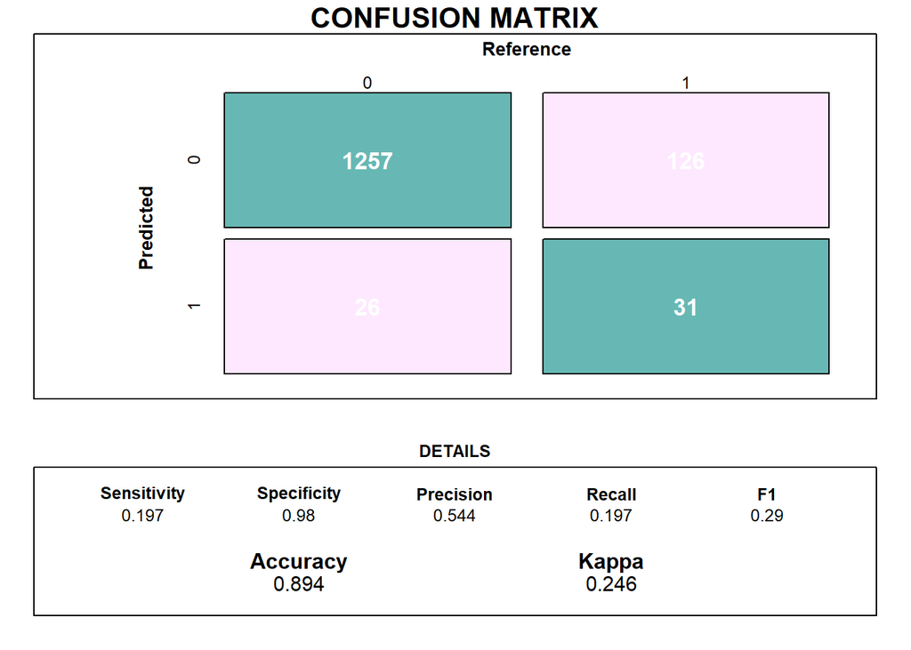

```r
cm0 <- caret::confusionMatrix(testProbs0$predOutcome, testProbs0$Outcome,
                       positive = "1")
draw_confusion_matrix(cm0)
```

Here is the updated confusion matrix. Conpared to the original one, the result stayed almost the same, but there is also a slight rise of Sensitivity and Specificity, which indicate the True Positive result increased, which is important to the final revenue.

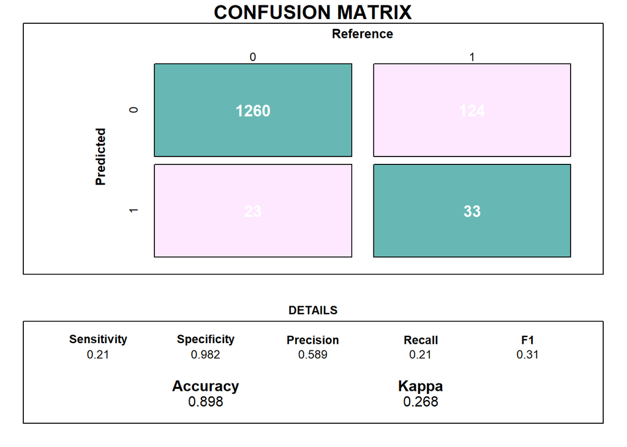

```r
cm <- caret::confusionMatrix(testProbs$predOutcome, testProbs$Outcome,
                       positive = "1")
draw_confusion_matrix(cm)
```

## Model performance comparison

In the next part, we analyze and draw the new and old models respectively. We have produced distribution of probabilities, ROC Curve, and Linear Model Analysis, as well as goodness of fit. The new model, as we said before, slightly improves the output and sensitivity.

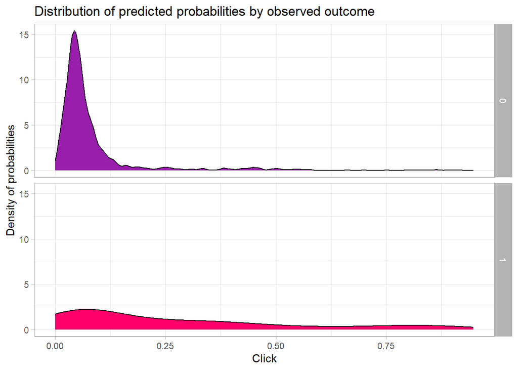

```r
ggplot(testProbs0, aes(x = Probs, fill = as.factor(Outcome))) +
  geom_density() +
      theme_light()+
  facet_grid(Outcome ~ .) +
  scale_fill_manual(values = palette2) +
  labs(x = "Click", y = "Density of probabilities",
       title = "Distribution of predicted probabilities by observed outcome") +
  theme(strip.text.x = element_text(size = 18),
        legend.position = "none")
```

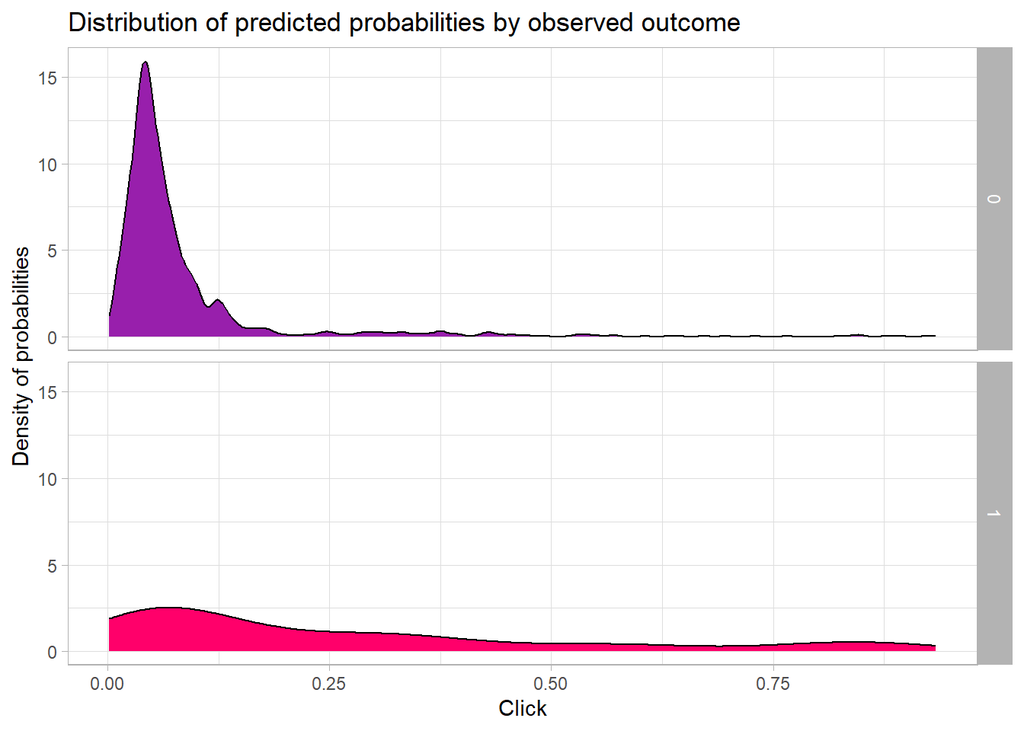

```r
ggplot(testProbs, aes(x = Probs, fill = as.factor(Outcome))) +
  geom_density() +
      theme_light()+
  facet_grid(Outcome ~ .) +
  scale_fill_manual(values = palette2) +
  labs(x = "Click", y = "Density of probabilities",
       title = "Distribution of predicted probabilities by observed outcome") +
  theme(strip.text.x = element_text(size = 18),
        legend.position = "none")
```